# Exploring Berkeley Admissions Data

Practice with Categorical Variables

P. Lombardo

## Loading packages and data

```r
library(tidyverse)
berkeley<-read.csv('data/berkeley.csv', header = T,
              stringsAsFactors = T)
```

## Getting started with statistical thinking

Above we loaded the Berkeley data set, which looks at acceptance rates to programs in 1973.

How many variables are there in this data set? What are they?

```r
#place code here
dim(berkeley)
```

```
## [1] 12763     3
```

```r
str(berkeley)
```

```
## 'data.frame':    12763 obs. of  3 variables:
##  $ Major    : Factor w/ 7 levels "A","B","C","D",..: 3 2 7 7 7 7 6 7 7 1 ...
##  $ Gender   : Factor w/ 2 levels "F","M": 1 2 1 2 2 2 1 2 2 2 ...
##  $ Admission: Factor w/ 2 levels "Accepted","Rejected": 2 1 1 1 2 2 1 1 2 1 ...
```

```r
names(berkeley)
```

```
## [1] "Major"     "Gender"    "Admission"
```

The original intent of this data was to explore whether there was a gender bias in Berkeley college admissions at that time. What initial summary helps us answer this question?

- Explanatory variable: **Gender**
- Response variable: **Admission**

We want a summary table that compares the acceptance rates between males and females:

- Gender on Rows, Admission on Columns
- Summarize by proportions using *row* totals.

```r
#place code here
berkeley %>%
    select(Gender, Admission) %>%
    table() %>%
    prop.table(margin = 1)
```

```
##       Admission
## Gender  Accepted  Rejected
##      F 0.3457533 0.6542467
##      M 0.4427861 0.5572139
```

Often in *observational studies*, where there is no experimental assignment of a treatment, a “confounding variable” can have an influencing effect on the research question, making a straightforward analysis like the one we did above not really capture the nuance of the situation.

With this in mind, create a summary table that compares acceptance rates for males and females, *but broken up by `Major`*. As usual, provide an appropriate visual as well.

```r
#place code here
berkeley %>%
    select(Gender, Admission, Major) %>%
    table() %>%
    prop.table(margin = c(1,3) )
```

```
## , , Major = A
##
##       Admission
## Gender   Accepted   Rejected
##      F 0.82407407 0.17592593
##      M 0.72495606 0.27504394
##
## , , Major = B
##
##       Admission
## Gender   Accepted   Rejected
##      F 0.68000000 0.32000000
##      M 0.63035714 0.36964286
##
## , , Major = C
##
##       Admission
## Gender   Accepted   Rejected
##      F 0.33895447 0.66104553
##      M 0.36923077 0.63076923
##
## , , Major = D
##
##       Admission
## Gender   Accepted   Rejected
##      F 0.34933333 0.65066667
##      M 0.33093525 0.66906475
##
## , , Major = E
##
##       Admission
## Gender   Accepted   Rejected
##      F 0.23918575 0.76081425
##      M 0.27748691 0.72251309
##
## , , Major = F
##
##       Admission
## Gender   Accepted   Rejected
##      F 0.07331378 0.92668622
##      M 0.05898123 0.94101877
##
## , , Major = Other
##
##       Admission
## Gender   Accepted   Rejected
##      F 0.37691070 0.62308930
##      M 0.40952556 0.59047444
```

What do you notice? Something surprising?

*After accounting for `Major`, the trend of males having an admissions advantage either reversed or disappeared!*

This is an example of something called [Simpson’s Paradox](https://en.wikipedia.org/wiki/Simpson%27s_paradox), where there is a clear trend when data is considered by groups separately, but that trend *reverses or disappears* when they groups are aggregated and treated as one.

Tricky, tricky, tricky….

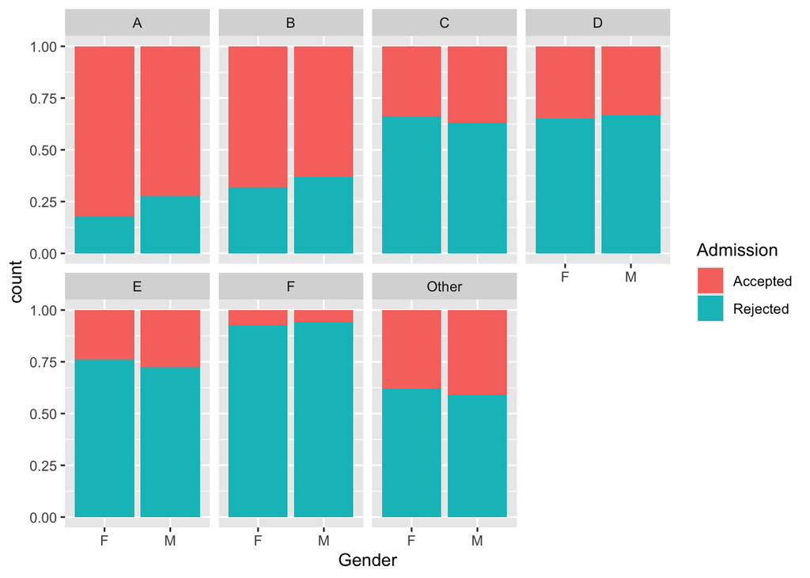

```r
ggplot(data = berkeley,
       aes(x = Gender, fill = Admission))+
    geom_bar(position="fill") +
    facet_wrap(vars(Major), nrow = 2)
```

Let’s use the remaining time to get started on our lab for the weekend!